# Baseline_evaluations

```python
import sys
from os.path import abspath
sys.path.insert(0, abspath('..'))

from os.path import join
from sklearn.cluster import KMeans

# CAEclust functionnalities
from CAEclust.io.dataLoader import dataLoader
from CAEclust.io.encodings_io import encodings_io
from CAEclust.clustering.ensClust import ensClust
from CAEclust.eval.evaluation import evaluate

MY_SEED = 24

%matplotlib inline
```

## Preparing the analysis

### Loading the training and test datasets

CAEclust proposes to easily load two well-known image datasets (**USPS** and **MNIST**) for autoencoder-based clustering. Each encoded version of the datasets is processed either with *k-means* or *LSC* (Landmark Spectral Clustering).

- **MNIST** The database is loaded from the {\tt Keras} Python package. The training and testing sets contain respectively 60,000 and 10,000 images of size 28x28 of the integers in range [0-9]. The images are of grayscale levels rescaled within [0,1] by dividing by 255.
- **USPS** The database is prepared as proposed in Guo *et al.* 2017 and contains 9,298 images of size 16x16 pixels of the 10 digits (integers in range [0-9]) rescaled within [0,1].

```python
# Dataset name
dataset = "MNIST" # MNIST or USPS

# Data directory
data_in_dir = join("..", "data")

# Loading the training/test datasets
# ----
my_data = dataLoader(dataName = dataset, inDataPath = join(data_in_dir, dataset))
my_data.getData(verbose = True)
```

```
# ------------------------
# Load MNIST data
# ----
# Training data
--
# Data type: float32
# Data range: [ 0.0 , 1.0 ]
# Data shape:  (60000, 784)
# Labels shape:  60000
----
# Test data
 --
# Data type: float32
# Data range: [ 0.0 , 1.0 ]
# Data shape:  (10000, 784)
# Labels shape:  10000
# ------------------------
```

### Setting the general parameters of the autoencoder

```python
# Autoencoders parameters
daeprocess = "serial"    # Choices: 'serial' or 'parallel'
encodings_param = {'outdir' : None, 'dataset' : dataset, 'enstype' : 'struct',

                   'optimfunc' : 'adam', 'lossfunc' : 'binary_crossentropy',
                   'internactiv' : 'relu', 'lastactiv' : 'sigmoid',

                   'nbatch' : 256, 'encoutdim' : 10, 'nens' : 6,
                   'nepoch' : [150], 'struct' : None}

# Pickle settings file name
dae_param_filename = "parameters.p"

# Output directory and list of encoded datasets
encodings = list()
top_encodings_out_dir = join(data_in_dir , "encodings")
```

## Clustering on original datasets

We first apply the *k-means* algorithm on the original training data. We then perform the Landmark-based Spectral Clustering, *LSC*. This first experiment provides a baseline score.

For **LSC**, we provide in CAEclust package a *Python* implementation that follows the *Matlab* implementation of Chen *et al.* (*Large Scale Spectral Clustering with Landmark-Based Representation*, AAAI 2011; Original source: http://www.cad.zju.edu.cn/home/dengcai/Data/code/LSC.m).

### k-means clustering on original data

```python
# Calling k-means clustering
my_kmeans = KMeans(n_clusters = my_data.k, random_state = MY_SEED).fit(my_data.data_train)

print("Predicted labels: ", my_kmeans.labels_)
```

```
Predicted labels:  [7 4 1 ... 7 6 2]
```

### Landmark-based spectral clustering on original data

```python
# Calling landmark-based spectral clustering
my_lsc = ensClust(my_seed = MY_SEED)
my_Z = my_lsc.single_approximate_affinity(data = my_data.data_train)
my_lsc.sparse_SVD(Z = my_Z, k = my_data.k)

print("Predicted labels: ", my_lsc.labels_)
```

```
Predicted labels:  [8 5 3 ... 8 7 4]
```

### Comparing k-means and LSC clusterings

```python
# Instanciating an evaluation object
my_eval = evaluate()

# Evaluating k-means and LSC clusterings
metrics_kmeans = my_eval.allMetrics(my_data.gt_train, my_kmeans.labels_)
metrics_lsc = my_eval.allMetrics(my_data.gt_train, my_lsc.labels_)

# Displaying comparative results
my_eval.compare_metrics(metrics_value = [metrics_kmeans, metrics_lsc], row_names = ['k-means', 'LSC'])
```

|  | ACC | NMI | ARI | mean |
| --- | --- | --- | --- | --- |
| LSC | 0.7098 | 0.7055 | 0.5937 | 0.6697 |
| k-means | 0.5129 | 0.4908 | 0.3606 | 0.4548 |

## Encoding the original data using a DAE

For the DAE, we provide the width of three hidden layers for the encoder part (e.g. [500,750,1000]). The decoder stage mirrors the encoder stage. The encoding layer is of size 10.

### Setting the specific parameters of the autoencoder for various structures

```python
# Specific settings for the encodings with various structures
encodings_param['struct'] = [[1000,750,500],[1000,500,750],
                             [750,1000,500],[750,500,1000],
                             [500,1000,750],[500,750,1000]]
encodings_param['nens'] = len(encodings_param['struct'])

# Name of the directory containing the encodings
encodings_param['outdir'] = join(top_encodings_out_dir, "CAEclust_baseline_{}".format(dataset))
```

### Encoding the data or load if already available

```python
# Instanciating and setting an encodings generator
my_encoder = encodings_io(encodings_param, daeprocess = daeprocess,
                          paramFile = dae_param_filename, verbose = True)

# Saving and/or loading the encodings corresponding to each structure
encodings, encodings_param = my_encoder.encodings_write_and_load(verbose = True)
```

```
# Loading encodings from '../data/encodings/CAEclust_baseline_MNIST'...
```

## Clustering on a deep representation

We first produce a **new representation** of the orginal data using the encoding layer of a **deep autoencoder** (DAE). We then apply the **k-means** and the **LSC** algorithms on this new representation.

```python
# Metrics results lists
metrics_dae_kmeans_struct = list()
metrics_dae_lsc_struct = list()
```

### Applying k-means on each deep data representation

```python
for i_struct, tmp_struct in enumerate(encodings_param['struct']):
    my_kmeans = KMeans(n_clusters = my_data.k, random_state = MY_SEED).fit(encodings[i_struct])

    print("Predicted labels with DAE [{}]: {}".format( ','.join(map(str, tmp_struct)), my_kmeans.labels_))

    metrics_dae_kmeans_struct.append(my_eval.allMetrics(my_data.gt_train, my_kmeans.labels_))
    del my_kmeans
```

```
Predicted labels with DAE [1000,750,500]: [9 6 8 ... 9 3 0]
Predicted labels with DAE [1000,500,750]: [4 2 3 ... 4 6 1]
Predicted labels with DAE [750,1000,500]: [2 3 4 ... 2 1 6]
Predicted labels with DAE [750,500,1000]: [3 2 4 ... 3 8 6]
Predicted labels with DAE [500,1000,750]: [4 3 7 ... 4 8 4]
Predicted labels with DAE [500,750,1000]: [3 5 4 ... 9 2 9]
```

### Applying LSC on each deep data representation

```python
for i_struct, tmp_struct in enumerate(encodings_param['struct']):
    my_dae_lsc = ensClust(my_seed = MY_SEED)
    my_Z = my_dae_lsc.single_approximate_affinity(data = encodings[i_struct])
    my_dae_lsc.sparse_SVD(Z = my_Z, k = my_data.k)

    print("Predicted labels with DAE [{}]: {}".format( ','.join(map(str, tmp_struct)), my_dae_lsc.labels_))

    metrics_dae_lsc_struct.append(my_eval.allMetrics(my_data.gt_train, my_dae_lsc.labels_))
    del my_dae_lsc
```

```
Predicted labels with DAE [1000,750,500]: [3 4 2 ... 3 5 9]
Predicted labels with DAE [1000,500,750]: [9 2 7 ... 9 4 5]
Predicted labels with DAE [750,1000,500]: [7 5 8 ... 7 4 1]
Predicted labels with DAE [750,500,1000]: [5 3 6 ... 5 1 9]
Predicted labels with DAE [500,1000,750]: [4 9 3 ... 4 8 1]
Predicted labels with DAE [500,750,1000]: [9 6 5 ... 9 1 4]
```

## Summarizing the evaluations

### Comparing *k-means*, *LSC*

```python
# Displaying comparative results for k-means and LSC on original data
my_eval.compare_metrics(metrics_value = [metrics_kmeans, metrics_lsc], row_names = ['k-means', 'LSC'])
```

|  | ACC | NMI | ARI | mean |
| --- | --- | --- | --- | --- |
| LSC | 0.7098 | 0.7055 | 0.5937 | 0.6697 |
| k-means | 0.5129 | 0.4908 | 0.3606 | 0.4548 |

### Comparing *k-means* and *DAE+k-means* on encodings based on different deep structures

```python
# Displaying comparative results for k-means on original data and encodings
all_metrics = [metrics_kmeans]; all_row_idx = ['k-means']

for iStruct in range(len(encodings_param['struct'])):
    all_metrics.append(metrics_dae_kmeans_struct[iStruct])
    all_row_idx.append('DAE ['+','.join(map(str, encodings_param['struct'][iStruct]))+'] + k-means ')

my_eval.compare_metrics(metrics_value = all_metrics, row_names = all_row_idx)
```

|  | ACC | NMI | ARI | mean |
| --- | --- | --- | --- | --- |
| DAE [500,1000,750] + k-means | 0.8932 | 0.7946 | 0.7882 | 0.8253 |
| DAE [1000,500,750] + k-means | 0.8957 | 0.7929 | 0.7857 | 0.8248 |
| DAE [500,750,1000] + k-means | 0.8229 | 0.7336 | 0.6876 | 0.7480 |
| DAE [750,1000,500] + k-means | 0.7776 | 0.7103 | 0.6480 | 0.7120 |
| DAE [1000,750,500] + k-means | 0.7665 | 0.6869 | 0.6219 | 0.6918 |
| DAE [750,500,1000] + k-means | 0.6278 | 0.6215 | 0.4903 | 0.5799 |
| k-means | 0.5129 | 0.4908 | 0.3606 | 0.4548 |

### Comparing *LSC* and *DAE+LSC* on encodings based on different deep structures

```python
# Displaying comparative results for LSC on original data and encodings
all_metrics = [metrics_lsc]; all_row_idx = ['LSC']

for iStruct in range(len(encodings_param['struct'])):
    all_metrics.append(metrics_dae_lsc_struct[iStruct])
    all_row_idx.append('DAE ['+','.join(map(str, encodings_param['struct'][iStruct]))+'] + LSC ')

html_res = my_eval.compare_metrics(metrics_value = all_metrics, row_names = all_row_idx)
html_res
```

|  | ACC | NMI | ARI | mean |
| --- | --- | --- | --- | --- |
| DAE [1000,500,750] + LSC | 0.9571 | 0.8956 | 0.9080 | 0.9202 |
| DAE [500,1000,750] + LSC | 0.9522 | 0.8873 | 0.8986 | 0.9127 |
| DAE [750,1000,500] + LSC | 0.9378 | 0.8624 | 0.8695 | 0.8899 |
| DAE [500,750,1000] + LSC | 0.9338 | 0.8592 | 0.8622 | 0.8851 |
| DAE [1000,750,500] + LSC | 0.8285 | 0.7628 | 0.7237 | 0.7717 |
| DAE [750,500,1000] + LSC | 0.7719 | 0.7096 | 0.6185 | 0.7000 |
| LSC | 0.7098 | 0.7055 | 0.5937 | 0.6697 |

### UMAP visualization of the best and the worst encodings

```python
# Get best and worse encoding from sorted results with LSC
l = [','.join([str(e) for e in item]) for item in encodings_param['struct']]
l_sort = [st[st.find("[")+1:st.rfind("]")] for st in html_res.index if "[" in st]
index_best = [idx for idx, s in enumerate(l) if s in l_sort[0]][0]
index_worse = [idx for idx, s in enumerate(l) if s in l_sort[len(l_sort)-1]][0]
```

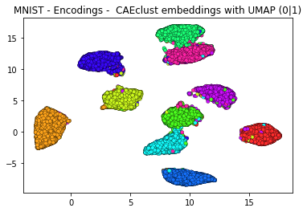

```python
# UMAP visualization of the best encoding (first DAE row in html table)
ax = my_eval.commonSpace_plot(B = encodings[index_best], comp = [0,1], tagLabels = my_data.gt_train,
                       data_name = dataset+" - Encodings - ", is_umap = True)
```

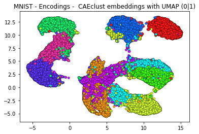

```python
# UMAP visualization of the worst encoding (last DAE row in html table)
ax = my_eval.commonSpace_plot(B = encodings[index_worse], comp = [0,1], tagLabels = my_data.gt_train,
                       data_name = dataset+" - Encodings - ", is_umap = True)
```